# weekly_junly1

Dohun Lee

2022-07-01

This is a RMDmarkdown to track and show progress between 30/06/22 ~ 06/07/22.

There were 3 main things to tackle:

1. Reproduce figure 3C
2. Make estimateRGaussian() work with nstates = 3
- Check why there is an error for patient 1439
- Is there really a problem if EM requires more than 800 steps? Try increasing this. -> 1500, got rid of all NAs, what are its implications
- reRun for all patients can collect results for all -> DONE - Record nrow(seg.dcn.toUse)
3. Append purity and subclonal ratios of each patient-time sample onto RECIST

# 1. Figure 3C

Figure 3C is showing…: *“Copy number profile of sample, with raw bin-wise and segmented copy number values shown in black and red, respectively.”*

Can we colour in the segments that liquidCNA designates to be sub-clonal and is used to estimate sub-clonal ratio?

**Problem 1: the segments used in liquidCNA are ensemble segments, so are subsets of segments identified in QDNAseq.**

Answer 1: we do have start and end (bin number, i.e., row of seg.df) for ensemble segments

```r
head(patient1.seg.data)
```

```
##   start  end length
## 1     1  386    386
## 2   387  787    401
## 3   788 1139    352
## 4  1140 1462    323
## 5  1463 1771    309
## 6  1772 2074    303
```

**Problem 2: How can I parse through a QDNAseq data object? Can data regarding ensemble segments be appended then plotted?**

```r
copyNumbersSegmented
```

```
## QDNAseqCopyNumbers (storageMode: lockedEnvironment)
## assayData: 6188 features, 3 samples
##   element names: copynumber, segmented
## protocolData: none
## phenoData
##   sampleNames: SLX-17922.D705tp_D507tp.HC22GBBXY.s_6.r_1
##     SLX-17922.D705tp_D508tp.HC22GBBXY.s_6.r_1
##     SLX-17921.D702tp_D501tp.H5J55BBXY.s_8.r_1
##   varLabels: name total.reads ... loess.family (6 total)
##   varMetadata: labelDescription
## featureData
##   featureNames: 1:1-500000 1:500001-1000000 ... Y:57000001-57227415
##     (6188 total)
##   fvarLabels: chromosome start ... use (9 total)
##   fvarMetadata: labelDescription
## experimentData: use 'experimentData(object)'
## Annotation:
```

```
## Plotting sample SLX-17922.D705tp_D507tp.HC22GBBXY.s_6.r_1 (2,408,687 reads) (1 of 3) ...
## Plotting sample SLX-17922.D705tp_D508tp.HC22GBBXY.s_6.r_1 (2,548,208 reads) (2 of 3) ...
```

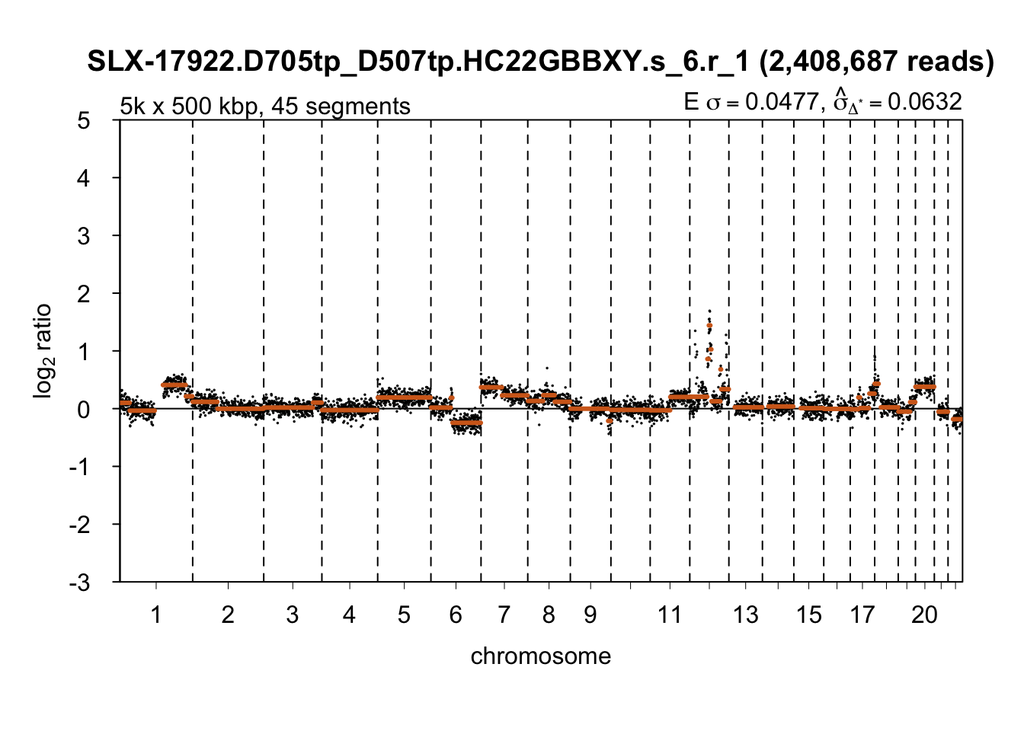

```
##
## Plotting sample SLX-17921.D702tp_D501tp.H5J55BBXY.s_8.r_1 (1,600,727 reads) (3 of 3) ...
```

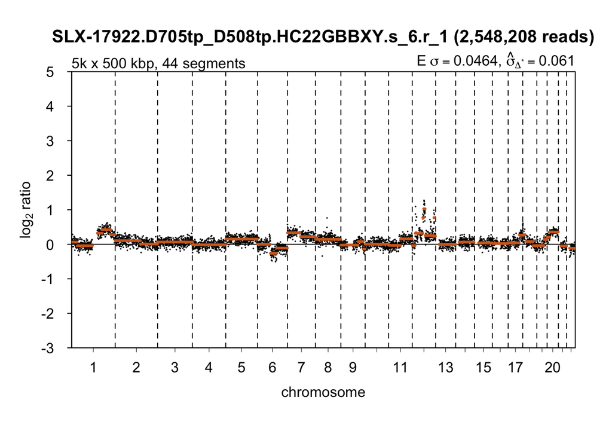

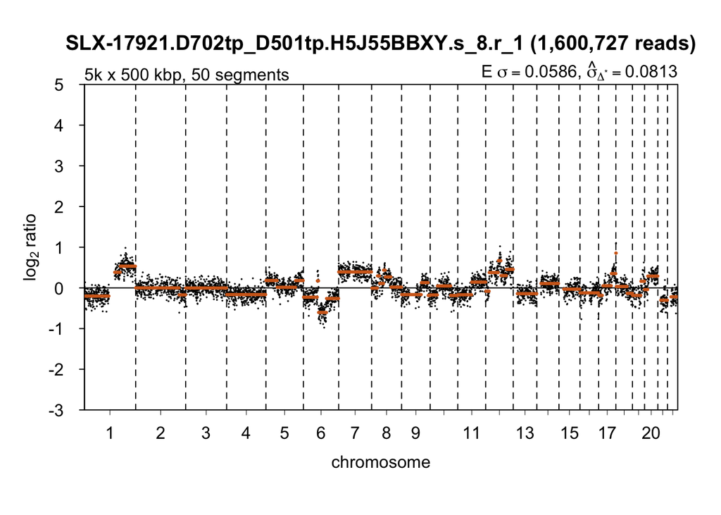

```r
plot(copyNumbersSegmented)
```

# 2. Run liquidCNA for all patients and study the results

## Run for normal patients

```r
#Patients with only two samples
sample_num_patient <- sapply(1:80, function(x) length(bam_by_patient[[x]]))
two_samp_patients <- which(sample_num_patient == 2)

#Patients with over 6 samples
timely_patients <- which(sample_num_patient > 6)

go_patients <- 1:80
go_patients <- go_patients[!(go_patients %in% two_samp_patients)]
go_patients <- go_patients[!(go_patients %in% timely_patients)]
```

Run!

```r
#initialise results vector
go_results <- vector(mode = "list", length = length(go_patients))

#Run for go_patients (i.e., non 2 or timely sample patients)
for(patient_x in 1:length(go_patients)){
  tryCatch({
    cat("Starting patient :", patient_x, "\n")
    go_results[[patient_x]] <- run_liquidCNA(go_patients[patient_x])
  }, error=function(e){cat("ERROR at:", go_patients[patient_x], "\n")})
}

names(go_results) <- paste0("patient_",patient_ids[go_patients])
```

### GO: Investigate error

Investigate:

- patients with NULL results,
- patients with NA for absolute value,
- patients with absolute ratio out of boundary of 0~1. <- in fact, rat is absolute ratio so a rat value outside of boundary would be fine? as negative value means less subclones than base sample, and rat > 1 is simply that much more than the base sample?

```r
#NULL results
null_go <- go_patients[which(sapply(1:length(go_patients), function(x) is.null(go_results[[x]])))]
null_go
```

```
## [1] 12 20 51 57 64
```

```r
#NA absolute - all time samples have an absolute ratio
any(sapply(1:length(go_patients), function(x) any(is.na(go_results[[x]]$rat))))
```

```
## [1] FALSE
```

```r
#absolute smaller than 0 - NONE
any(sapply(1:length(go_patients), function(x) any(as.numeric(go_results[[x]]$rat) < 0)))
```

```
## [1] FALSE
```

```r
#absolute greater than 1 - absolute ratio so bigger than 1 is fine?
big_rat_go <- which(sapply(1:length(go_patients), function(x) any(as.numeric(go_results[[x]]$rat) > 1)))
  #ids of patients with rat > 1
patient_ids[go_patients[big_rat_go]]
```

```
##  [1]  392 2484 2587 2734 2757 2806 3080 3134 3301 3355 3439 3488 3614 3779 3882
```

Tackle NULL patients, where is the ERROR coming from? and how can we fix it?

## Run for two sample patients

Run!

```r
#initialise results vector
two_samp_results <- vector(mode = "list", length = length(two_samp_patients))

#run!
for(patient_x in 1:length(two_samp_patients)){
  tryCatch({
    cat("Starting patient :", patient_x, "\n")
    two_samp_results[[patient_x]] <- run_2samp_liquidCNA(two_samp_patients[patient_x])
  }, error=function(e){cat("ERROR at:", patient_x, "\n")})
}

names(two_samp_results) <- paste0("patient_",patient_ids[two_samp_patients])
```

```r
head(two_samp_results)
```

```
## $patient_957
##      time relratio                 rat            rat_sd purity_mean
## 1 Sample2     <NA> -0.0276049154450593 0.223902321813232        0.05
## 2 Sample1        0                   0                 0       0.065
##   purity_median seg_used cutOff
## 1          0.05       25   0.26
## 2         0.065       25   0.26
##
## $patient_1333
##      time relratio                  rat             rat_sd purity_mean
## 1 Sample2     <NA> -0.00707406446555313 0.0596411861076184        0.05
## 2 Sample1        0                    0                  0        0.05
##   purity_median seg_used cutOff
## 1          0.05       19   0.26
## 2          0.05       19   0.26
##
## $patient_2487
##      time relratio               rat            rat_sd purity_mean
## 1 Sample2     <NA> 0.197495045589614 0.260893008031703       0.225
## 2 Sample1        0                 0                 0        0.05
##   purity_median seg_used cutOff
## 1          0.23       34   0.26
## 2          0.05       34   0.26
##
## $patient_2511
##      time relratio                 rat             rat_sd purity_mean
## 1 Sample2     <NA> -0.0900267083669209 0.0934199159675127        0.05
## 2 Sample1        0                   0                  0        0.05
##   purity_median seg_used cutOff
## 1          0.05       19   0.26
## 2          0.05       19   0.26
##
## $patient_2759
##      time relratio              rat            rat_sd purity_mean purity_median
## 1 Sample2     <NA> 1.10170774264286 0.705661386171779        0.05          0.05
## 2 Sample1        0                0                 0       0.155         0.155
##   seg_used cutOff
## 1       46   0.26
## 2       46   0.26
##
## $patient_2788
##      time relratio               rat            rat_sd purity_mean
## 1 Sample2     <NA> 0.354440270036175 0.456320914436696         0.5
## 2 Sample1        0                 0                 0        0.05
##   purity_median seg_used cutOff
## 1           0.5       35   0.26
## 2          0.05       35   0.26
```

## Run for 6+ patients

```r
#number of BAM files our timely patients have
timely_bam_num <- sample_num_patient[timely_patients]

#number of bam files to batch each timely patient by:
nbatch1 <- ceiling(timely_bam_num/2)
nbatch2 <- timely_bam_num - nbatch1

#initialise result vector
timely_res1 <- vector(mode = "list", length = length(timely_patients))
timely_res2 <- vector(mode = "list", length = length(timely_patients))

#RUN!
for(x in 1:length(timely_patients)){
  tryCatch({
    cat("\n Starting", x, "\n")
    timely_res1[[x]] <- run_liquidCNA(timely_patients[x],
                               timely = TRUE,
                               batch1 = TRUE,
                               nbatch = nbatch1[x])
  }, error=function(e){cat("ERROR at:", x, "\n")})
}

for(x in 1:length(timely_patients)){
  tryCatch({
    cat("\n Starting", x, "\n")
    timely_res2[[x]] <- run_liquidCNA(timely_patients[x],
                               timely = TRUE,
                               batch1 = FALSE,
                               nbatch = nbatch2[x])
  }, error=function(e){cat("ERROR at:", x, "\n")})
}

names(timely_res1) <- paste0("patient_",patient_ids[timely_patients],"_batch1")
names(timely_res2) <- paste0("patient_",patient_ids[timely_patients],"_batch2")
```

### Timely: Investigate error

I think this may be due to erroneous BAM file present for this patient - not sure why though…

Erroneous BAM file: SLX.17921.D701tp_D505tp.H5J55BBXY.s_8.r_1

```r
error_seg.df <- read.delim(paste0("../DATA/2_QDNA_CNout/segment_2789_og.txt"))
error_seg.df <- error_seg.df[,-(1:4)]
colnames(error_seg.df) <- paste0("Sample", 1:ncol(error_seg.df))
head(error_seg.df)
```

```
##   Sample1 Sample2 Sample3 Sample4 Sample5 Sample6  Sample7 Sample8
## 1   0.962   1.007   1.006    1.01    1.01   0.956 7176.137   1.003
## 2   0.962   1.007   1.006    1.01    1.01   0.956 7176.137   1.003
## 3   0.962   1.007   1.006    1.01    1.01   0.956 7176.137   1.003
## 4   0.962   1.007   1.006    1.01    1.01   0.956 7176.137   1.003
## 5   0.962   1.007   1.006    1.01    1.01   0.956 7176.137   1.003
## 6   0.962   1.007   1.006    1.01    1.01   0.956 7176.137   1.003
```

### Stitch Timely

Question - for the results, how are the rows ordered? should i reorder them so they just go up? this won’t take long just look A - in final.results, rows are ordered in the sample order found by liquidCNA with base sample appended in the final row

**Problem: this method of stitching doesn’t make sense. as the assumption of liquidCNA, results the base sample of second batch to have sub-clonality of 0**

```r
batch1_rat <- as.numeric(timely_res1[[1]]$rat)
batch2_rat <- as.numeric(timely_res2[[1]]$rat)

batch1_rat
```

```
## [1] 0.8159024 0.5826309 0.8385415 0.5075310 1.5933576 0.0000000
```

```r
batch2_rat
```

```
## [1] 0.8418877 0.1535028 0.3528716 0.8427729 0.0000000
```

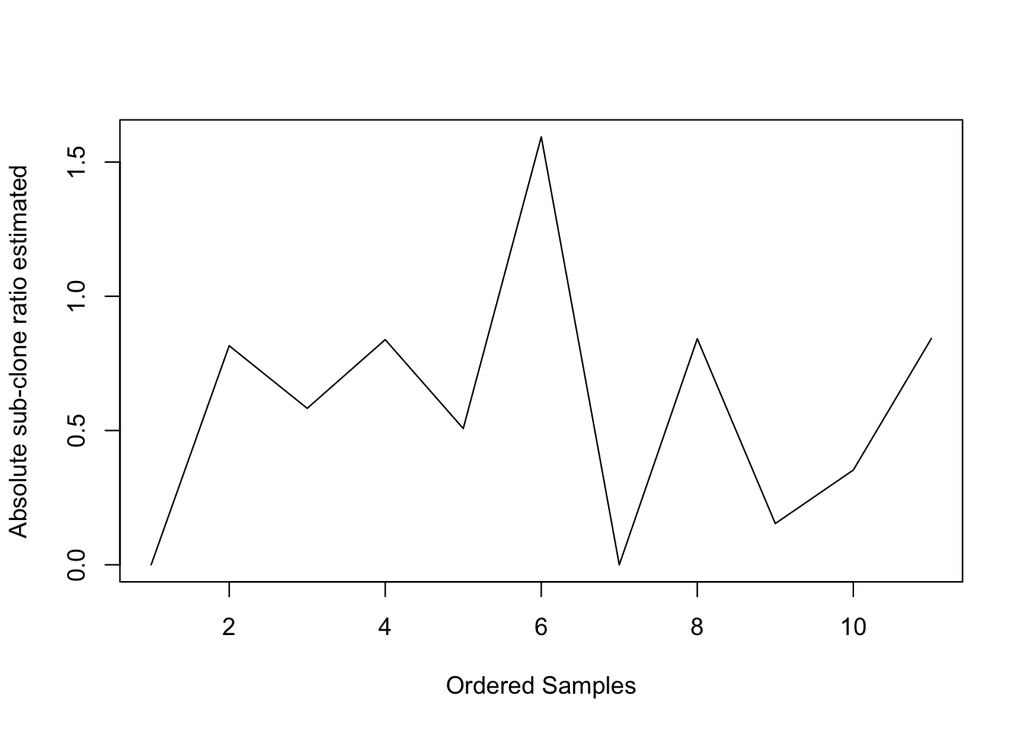

```r
rat_ordered <- c(batch1_rat[length(batch1_rat)], batch1_rat[1:(length(batch1_rat)-1)], batch2_rat[length(batch2_rat)], batch2_rat[1:(length(batch2_rat)-1)])

plot(rat_ordered, type = "l", ylab = "Absolute sub-clone ratio estimated",
     xlab = "Ordered Samples")
```